# Exercise 4 : Rasters and Vectors together in action

Marta Bernardi

2024-04-03

### Key packages

- Geo-computations : sf, terra, raster , ncdf4, exactextractr, rgdgal
- Plotting : ggplot2, ggrepel, gridExtra, ggspatial, grid
- Geocoding : tidygeocoder
- R Project management: here
- Generic data wrangling : dplyr, tidyr
- Map of the world : rnaturalearth, rnaturalearthdata, elevatr
- Country and admin names : countrycode
- Open street maps : osrm

First some spatial topological gymnastic to refresh memory on vectors:

## 1: Spatial vector operations

##- 1.1: Topological relations : st_within(), st_touches(), st_is_within_distance(), st_disjoint()

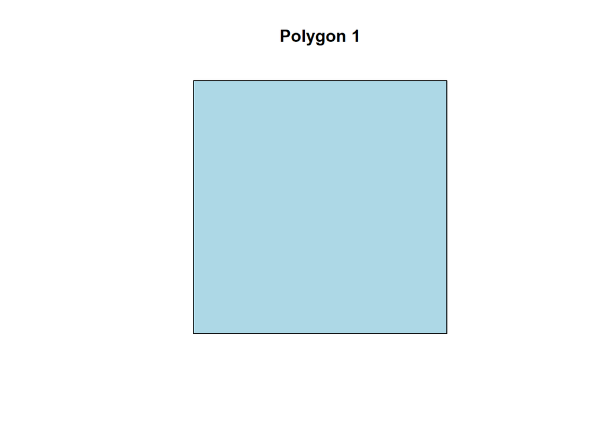

```r
# let's create some sample data

polygon1 <- st_polygon(list(rbind(c(0, 0), c(0.5, 0), c(0.5, 0.5), c(0, 0.5), c(0, 0))))
polygon2 <- st_polygon(list(rbind(c(0.5, 0.5), c(1.5, 0.5), c(0.8, 0.8), c(0.5, 0.8), c(0.5, 0.5))))
point <- st_point(c(0.5, 0.5))

plot(polygon1, col = "lightblue", main = "Polygon 1")
```

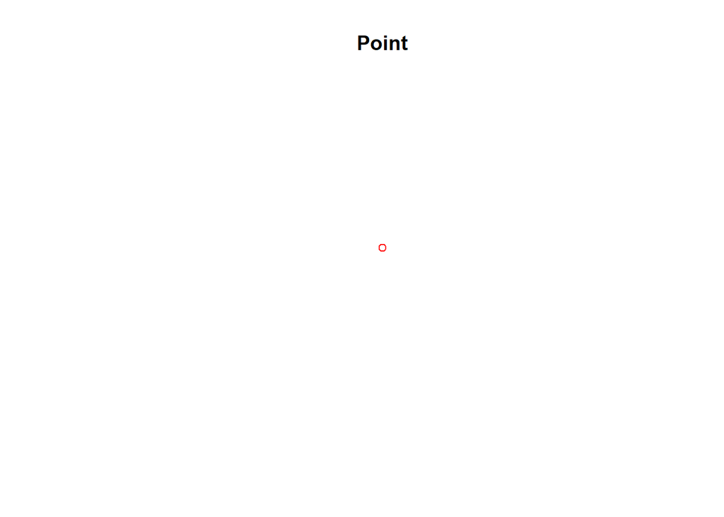

```r
plot(point, add = FALSE, col = "red", main = "Point")
```

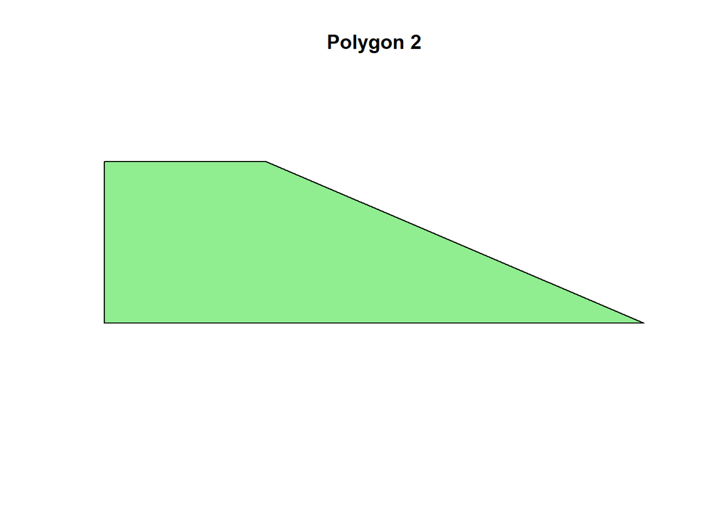

```r
plot(polygon2, col = "lightgreen", main = "Polygon 2")
```